# How to use PCA using h2o package

Tran Le

7/21/2021

# 1 Intro

This is a file for learning to apply PCA with h2o package  
This file summaries the content from: https://bradleyboehmke.github.io/HOML/ (Chapter 17)  
Goal:  
1- Understanding how to apply PCA with h2o  
2- Create a cheat sheet for later reference. 3- All of the useful contents are put in different functions that can be easily+conveniently used for bigger projects

# 2 Load Data

Data set: my_basket: identifies items and quantities purchased for 2,000 transactions from a grocery store.  
Objective: is to identify common groupings of items purchased together.

```r
library(tidyverse)
library(dplyr)       # basic data manipulation and plotting
library(ggplot2)     # data visualization
library(h2o)
url <- "https://koalaverse.github.io/homlr/data/my_basket.csv"
my_basket <- readr::read_csv(url)
dim(my_basket)
```

```
  [1] 2000   42
```

```r
head(my_basket)
```

```
  # A tibble: 6 x 42
    `7up` lasagna pepsi   yop red.wine cheese   bbq bulmers mayonnaise horlics
    <dbl>   <dbl> <dbl> <dbl>    <dbl>  <dbl> <dbl>   <dbl>      <dbl>   <dbl>
  1     0       0     0     0        0      0     0       0          0       0
  2     0       0     0     0        0      0     0       0          0       0
  3     0       0     0     0        0      0     0       0          0       0
  4     0       0     0     2        1      0     0       0          0       0
  5     0       0     0     0        0      0     0       2          0       0
  6     0       0     0     0        0      0     0       0          0       0
  # ... with 32 more variables: chicken.tikka <dbl>, milk <dbl>, mars <dbl>,
  #   coke <dbl>, lottery <dbl>, bread <dbl>, pizza <dbl>, sunny.delight <dbl>,
  #   ham <dbl>, lettuce <dbl>, kronenbourg <dbl>, leeks <dbl>, fanta <dbl>,
  #   tea <dbl>, whiskey <dbl>, peas <dbl>, newspaper <dbl>, muesli <dbl>,
  #   white.wine <dbl>, carrots <dbl>, spinach <dbl>, pate <dbl>,
  #   instant.coffee <dbl>, twix <dbl>, potatoes <dbl>, fosters <dbl>,
  #   soup <dbl>, toad.in.hole <dbl>, coco.pops <dbl>, kitkat <dbl>,
  #   broccoli <dbl>, cigarettes <dbl>
```

# 3 Perform PCA in R

- To perform reduction techniques in R:

$$\begin{cases}
\text{Data are in tidy format} \\
\text{No missing values}\\
\text{the data must all be numeric values (e.g., one-hot, label, ordinal encoding categorical features)} \\
\text{Numeric data should be standardized (e.g., centered and scaled) to make features comparable.}
\end{cases}$$

- Some notes for `pca_method`:
  - When data contains **mostly numeric** data its best to use **pca_method = “GramSVD”**.
  - When your data contain many **categorical variables** (or just a few categorical variables with high cardinality): use **pca_method = “GLRM”**. Also, you need to add the argument *use_all_factor_levels = TRUE* since the GLRM only implemented when this argument has TRUE value.

```r
h2o.no_progress()  # turn off progress bars for brevity
h2o.init(max_mem_size = "5g")  # connect to H2O instance
```

[output not shown]

```r
my_basket.h2o <- as.h2o(my_basket) # this step is a must
```

```r
run_PCA_f <- function(train, method, k, transform, max_runtime_secs, folder="./Figures/"){
  ## train: non-mising-value, h2o data
  ## k: numer of PCs
  ## transform: a "text"  for tranforming method
  ##folder: "direction to the folder that you want to save your figures"
  #
  #perform the PCA
  my_pca <- h2o.prcomp(
            training_frame = train,
            pca_method = method,
            k = k,
            transform = transform,
            max_runtime_secs = max_runtime_secs,
            impute_missing = TRUE,
            seed = 72873)
  # ## Plot the contribution to the pc1
  png(paste0(folder, "influence_to_", "pc1", ".png"))
  theplot <-  my_pca@model$eigenvectors %>% as.data.frame() %>%
              mutate(feature = row.names(.)) %>%
              ggplot(aes(pc1, reorder(feature, pc1))) + geom_point()
  print(theplot)
  dev.off()
  ## Feature contribution for pc1 and pc2
  png(paste0(folder, "feature_to_", "pc1_pc2", ".png"))
  theplot <- my_pca@model$eigenvectors %>% as.data.frame() %>% mutate(feature = row.names(.)) %>%
             ggplot(aes(pc1, pc2, label = feature)) + geom_text()
    print(theplot)
  dev.off()
  #
  return(my_pca)
}
```

> use `glimpse(my_pca)` to see information of my_pca. The most important information is stored in `my_pca@model$importance`.

```r
my_pca <- run_PCA_f(train = my_basket.h2o,
                    method = "GramSVD",
                    k = ncol(my_basket.h2o),
                    transform  = "STANDARDIZE",
                    max_runtime_secs = 1000)
#glimpse(my_pca)
```

# 4 Selecting the number of PCs

- There are three common approaches to select the number of PCs:
  1. Eigenvalue criterion
  2. Proportion of variance explained criterion
  3. Scree plot criterion

## 4.1 Eigenvalue criterion

```r
find_numPCs_by_eigen_f <- function(my_pca){
  # my_pca: a result of runing h2o.prcomp
  # num_PCs: number of Pcs having eigen_value>=1, this is the number of PCs needed by using eigenvalue criterion
  # Compute eigenvalues
  eigen <- my_pca@model$importance["Standard deviation", ] %>% as.vector() %>% .^2
  ##
  cat("Sum of all eigenvalues equals number of variables:", sum(eigen), "\n")
  cat("Find PCs where the sum of eigenvalues is greater than or equal to 1: ", which(eigen >= 1), "\n")
  num_PCs = length(which(eigen >= 1))
  return(num_PCs)
}
```

```r
num_PCs <- find_numPCs_by_eigen_f(my_pca)
```

```
  Sum of all eigenvalues equals number of variables: 42
  Find PCs where the sum of eigenvalues is greater than or equal to 1:  1 2 3 4 5 6 7 8 9 10
```

```r
cat("Number of Pcs need to use by eigen value criteria: ",num_PCs )
```

```
  Number of Pcs need to use by eigen value criteria:  10
```

## 4.2 Proportion of variance explained criterion

```r
find_PVE_CVE_f <- function(folder="./Figures/", my_pca){
  # folder: "link to the folder that you want to save your figure"
  # my_pca: a result of runing h2o.prcomp
  # percent_var_explain: a number in (0,1):  the cummulative variance explained that need to have
  # PVE: proportion of variance explained: identifies the optimal number of PCs to keep
  # based on the total variability that we would like to account for
  # CVE: cumulative variance explained
  # OUT:
  # num_PCs: the number of PCs need to archive percent_var_explain

  PVE_CVE_dat <- data.frame(
                  PC  = my_pca@model$importance %>% seq_along(),
                  PVE = my_pca@model$importance %>% .[2,] %>% unlist(),
                  CVE = my_pca@model$importance %>% .[3,] %>% unlist())
  # Plot the and save the PVE and CVE vs PCs
  png(paste0(folder, "PVE_CVE_PC.png"))
  theplot <-   PVE_CVE_dat %>% gather(metric, variance_explained, -PC) %>%
                ggplot(aes(PC, variance_explained)) +geom_point() +
              facet_wrap(~ metric, ncol = 1, scales = "free")
  print(theplot)
  dev.off()
  #
  return(PVE_CVE_dat)}

find_numPCs_by_eigen_f <- function(PVE_CVE_dat, percent_var_explain){
  # Get the number of Pcs needed to explain at least percent_var_explain*100% of total variability
  num_PCs <- min(which(PVE_CVE_dat$CVE >= percent_var_explain))
  return(num_PCs)
}
```

```r
PVE_CVE_dat <- find_PVE_CVE_f(folder="./Figures/", my_pca)
percent_var_explain=0.8
num_PCs_byvar <- find_numPCs_by_eigen_f(PVE_CVE_dat, percent_var_explain=percent_var_explain)
cat("Number of PCs needed to explain more than", percent_var_explain, "of variance:", num_PCs_byvar )
```

```
  Number of PCs needed to explain more than 0.8 of variance: 30
```

The PVE_CVE_PC plot can be shown by `![PVE_CVE_pC plot](./Figures/PVE_CVE_PC.png)`:

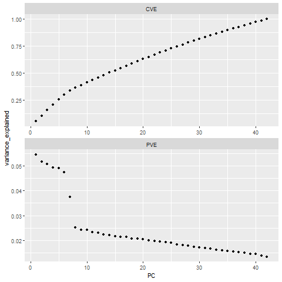

PVE_CVE_pC plot

## 4.3 Scree plot criterion

A scree plot shows the eigenvalues or PVE for each individual PC. The scree plot criterion looks for the “elbow” in the curve and selects all components just before the line flattens out

```r
find_PC_PVE_dat_f <- function(folder, my_pca){
  # folder: "link to the folder that you want to keep your Scree_plot"
  # my_pca: a result of h2o.prcomp() function

  PC_PVE_dat <- data.frame(
                PC  = my_pca@model$importance %>% seq_along,
                PVE = my_pca@model$importance %>% .[2,] %>% unlist())
  # Draw and save the scree plot
  png(paste0(folder, "/Scree_plot.png"))
  theplot <- PC_PVE_dat %>% ggplot(aes(PC, PVE, group = 1, label = PC)) +
             geom_point() + geom_line() + geom_text(nudge_y = -.002)
  print(theplot)
  dev.off()
  return(PC_PVE_dat)
}
```

```r
PVE_CVE_dat <- find_PC_PVE_dat_f("./Figures", my_pca)
```

Scree_plot then can be shown by `![Scree_plot](./Figures/Scree_plot.png)`:

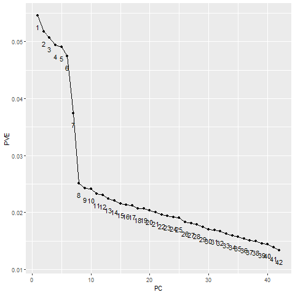

Scree_plot

# 5 What method I need to choose to find number of PCs?

The frank answer is that there is no one best method for determining how many components to use.

> PCA can be highly affected by outliers. [GLRM](https://bradleyboehmke.github.io/HOML/GLRM.html) discusses an alternative dimension reduction procedure that takes outliers into consideration, and [Autoencoders](https://bradleyboehmke.github.io/HOML/autoencoders.html) illustrates a procedure to help identify outliers.